# MIDI-MT - Specific MIDI-MT API objects in ChaiScripts

MIDI-MT Documentation in English

## Specific MIDI-MT API objects in «ChaiScript»

- MIDI-MT API Objects
  - Basic functions of the MIDI-MT API
    - Checking the execution cancellation status
    - Waiting and handling possible errors in a loop
    - Set and send a new value for a button
    - Set and send a new value for the slider
    - Getting a list of controls from a configuration file
    - Searching for a control in the configuration
  - Basic MIDI-MT API Objects
    - MMTConfig()
    - BaseUnit()
    - UnitValue()
    - MidiUnit()
    - MidiData()
    - Unit() (Color, Macro)
    - ColorCorrector()
    - RGBW()
    - Macro()
    - ColorIndex enumerator
    - ColorsIndex enumerator
    - TargetIndex enumerator
    - UnitTypeIndex enumerator
    - ClickTypeIndex enumerator
  - Specific container Objects
- ChaiScript documentation and examples
- Assigning scripts to MIDI-MT
- Settings of the scenario management module
- Brief information about the main characteristics of the ChaiScript language

```
     The scripting core of MIDI-MT is ChaiScript
     ChaiScript is a typed declarative language with syntax similar to C++, TypeScript and JavaScript.
```

#### Basic functions of the MIDI-MT API

- `sleep(milliseconds)` wait `X` milliseconds.
- `UpdateControlButton(scene, key)` “press button” `key` from scene `scene`.
- `UpdateControlSlider(scene, key, value)` apply the new `value` value to the `key` controller from the `scene` scene.
- `var list = MidiUnitsList()` get a list of controls from the configuration file.
- `var string_name = ScriptName()` get the name of the current script.
- `var number_hash = ScriptHash()` get a hash from the current script name.
- `var bool_value = IsCanceled()` get the status of possible cancellation of script execution.
- `var bool_value = IsDebugging()` get debugger connection status, for example `Dbgview` [x64](https://live.sysinternals.com/dbgview64.exe) | [x32](https://live.sysinternals.com/Dbgview.exe).

###### Checking the execution cancellation status:

In scripts using loops, be sure to check the script’s cancellation status, example:

```javascript
   while (!IsCanceled()) {
      // ... long job 1 ...
      if (IsCanceled()) { break; }
      // ... long job 2 ...
      if (IsCanceled()) { break; }
      // ... long job 3 ...
   }
```

###### Waiting and handling possible errors in a loop:

```javascript
   while (!IsCanceled()) {
      try {
          // ... job ...
       } catch (e) {
          print("Oops, found error: " + e.what());
          break;
       }
       if (IsCanceled()) { break; }
       // wait one second
       sleep(1000);
   }
```

###### Set and send a new value for a button:

```javascript
   var scene = 176;
   var key = 23;

   UpdateControlButton(scene, key);
   // or:
   UpdateControlButton(176, 23);
   // or best practice:
   UpdateControlButton(uint8_t(176), uint8_t(23));
```

###### Set and send a new value for the slider:

```javascript
   var scene = 176;
   var key = 44;
   var value = 42;

   UpdateControlSlider(scene, key, value);
   // or:
   UpdateControlSlider(176, 44, 42);
   // or best practice:
   UpdateControlSlider(uint8_t(176), uint8_t(44), uint8_t(42));
```

###### Getting a list of controls from a configuration file:

```javascript
   // Get all units list, from configuration file
   var list = MidiUnitsList();
   print(list);
   // or:
   for (auto i = 0; i < list.size(); ++i) {
      auto unit = list[i];
      print(unit);
   }
```

###### Searching for a control in the configuration:

```javascript
   var group = uint8_t(176);
   var key = uint8_t(3);
   var slider176_3 = Unit(group, key, uint8_t(42), UnitTypeIndex.SLIDER);

   var find_unit = FindMidiUnit(slider176_3);
   if (!find_unit.empty()) {
      print(find_unit);
   }
```

### Basic MIDI-MT API Objects

##### MMTConfig

constructor: **none**  
functions:

```javascript
   MMTConfig.Find(uint8_t)
   MMTConfig.Find(uint8_t, uint8_t)
   MMTConfig.Find(uint8_t, uint8_t, UnitTypeIndex)
   MMTConfig.Find(TargetIndex)
   MMTConfig.Add(MidiUnit)
   MMTConfig.clear()
   MMTConfig.empty()
   MMTConfig.dump()
```

variables:

```javascript
   MMTConfig.AutoStart
   MMTConfig.ConfigName
   MMTConfig.BuilderVersion
```

##### BaseUnit

constructor: `var bu = BaseUnit()`  
functions:

```javascript
   BaseUnit.empty()
   BaseUnit.dump()
```

variables:

```javascript
   BaseUnit.id
   BaseUnit.key
   BaseUnit.scene
   BaseUnit.target
   BaseUnit.longtarget
   BaseUnit.type
   BaseUnit.value
   BaseUnit.apps
```

##### MidiUnit

constructor: `var mu = MidiUnit()`  
functions:

```javascript
   MidiUnit.Equals(MidiUnit)
   MidiUnit.EqualsGroup(MidiUnit)
   MidiUnit.GetMixerId()
   MidiUnit.GetHash()
   MidiUnit.empty()
   MidiUnit.dump()
```

variables:

```javascript
   MidiUnit.id
   MidiUnit.key
   MidiUnit.scene
   MidiUnit.group
   MidiUnit.target
   MidiUnit.type
   MidiUnit.value
   MidiUnit.apps
```

##### UnitValue (MidiUnit.value(), MixerUnit.value)

constructor: `var uv = UnitValue()`  
functions:

```javascript
   UnitValue.empty()
   UnitValue.dump()
```

variables:

```javascript
   UnitValue.value
   UnitValue.onoff
   UnitValue.type
```

##### MidiData

constructor: `var md = MidiData()`  
functions:

```javascript
   MidiData.SetData(uint8_t, uint8_t, uint8_t, uint8_t, uint8_t)
   MidiData.SetValue(bool)
   MidiData.GetScene()
   MidiData.GetKey()
   MidiData.GetValue()
   MidiData.GetTarget()
   MidiData.Equals(MidiData)
   MidiData.clear()
   MidiData.empty()
   MidiData.dump()
```

##### Unit (Color unit, Macro unit)

constructor: `var unit = Unit()`  
additional constructors:

```javascript
   Unit(U8Vector, uint8_t)
   Unit(uint8_t, uint8_t, uint8_t)
   Unit(uint8_t, uint8_t, uint8_t, UnitTypeIndex)
```

functions:

```javascript
   Unit.GetType()
   Unit.SetValue()
   Unit.GetSene()
   Unit.GetKey()
   Unit.GetValue()
   Unit.empty()
   Unit.dump()
```

##### ColorCorrector

constructor: `var unit = ColorCorrector(r, g, b, w)` color correction value `-127` to `127`  
additional constructors:

```javascript
   ColorCorrector(8Vector)
```

functions:

```javascript
   ColorCorrector.Get()
   ColorCorrector.empty()
   ColorCorrector.dump()
```

##### RGBW

constructor: `var rgb = RGBW()`  
additional constructors:

```javascript
   RGBW(U8Vector, U8Vector, U8Vector)
   RGBW(U8Vector, U8Vector, U8Vector, U8Vector)
```

functions:

```javascript
   RGBW.SetColor(uint8_t, uint8_t, uint8_t, uint8_t)   // set RGBW color type
   RGBW.SetColor(uint16_t, uint8_t, uint8_t)           // set HSB/HSV color type
   RGBW.SetColor(ColorsIndex)                          // set RGBW color by index
   RGBW.SetHue(uint16_t)                               // set Hue: 0-359
   RGBW.SetSaturation(uint8_t)                         // set Saturation: 0-99
   RGBW.SetBrightness(uint8_t)                         // set Brightness: 0-99
   RGBW.FadeIn(size_t, size_t, size_t)                 // values -> start: 0-99, end: 0-99, wait: ms.
   RGBW.FadeOut(size_t, size_t, size_t)                // values -> start: 0-99, end: 0-99, wait: ms.
   RGBW.On()
   RGBW.Off()
   RGBW.R()
   RGBW.G()
   RGBW.B()
   RGBW.W()
   RGBW.GetColor(ColorIndex)
   RGBW.GetHue()
   RGBW.GetSaturation()
   RGBW.GetBrightness()
   RGBW.GetGroup()
   RGBW.ApplyValues()
   RGBW.UpdateValues()
   RGBW.empty()
   RGBW.dump()
```

utilites:

```javascript
   var group = 176;
   var key_red = 11;
   var key_green = 12;
   var key_blue = 13;
   var key_white = 14;

   auto rgb  = CreateRGB(uint8_t(group), uint8_t(key_red), uint8_t(key_green), uint8_t(key_blue));
   auto rgbw = CreateRGBW(uint8_t(group), uint8_t(key_red), uint8_t(key_green), uint8_t(key_blue), uint8_t(key_white));
```

An example of using additional constructors:

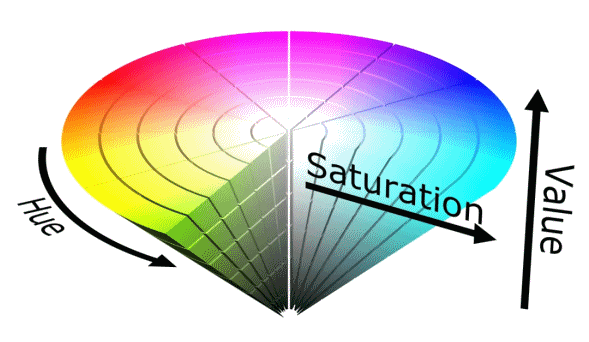

```javascript
   var v1 = U8Vector()
   v1.push_back(176)
   v1.push_back(11)

   var v2 = U8Vector()
   v2.push_back(176)
   v2.push_back(12)

   var v3 = U8Vector()
   v3.push_back(176)
   v3.push_back(13)

   var v4 = U8Vector()
   v4.push_back(176)
   v4.push_back(14)

   var color_control = RGBW(v4, v3, v2);

   // <- update values from configuration:
   color_control.UpdateValues();

   print(color_control);

   // color_control.SetColor(ColorsIndex.LIME);
   // or:
   // .SetColor(Hue, Saturation, Brightness);
   color_control.SetColor(180, 50, 99);

   // FadeIn / FadeOut (
   //   initial brightness value,
   //   final brightness value,
   //   delay in milliseconds
   // );
   color_control.FadeIn(0, 100, 200);
   color_control.FadeOut(100, 0, 200);
```

More about the color scheme [“HSB”/“HSV”](https://github.com/ClaudiaCoord/MIDI-EasyControl-to-Mackie-translator-for-Premiere-Pro/tree/main/docs/API/script/HSB-HSV-color-hue-saturation-brightness-EN.pdf)

##### Macro

constructor: `var macro = Macro()`  
functions:

```javascript
   Macro.Add(Unit)  // Unit(uint8_t, uint8_t, uint8_t, UnitTypeIndex)
   Macro.ApplyValues()
   Macro.UpdateValues()
   Macro.clear()
   Macro.empty()
   Macro.dump()
```

Example of using the `Macro` object:

```javascript
   var group = uint8_t(176);
   var key1 = uint8_t(11);
   var key2 = uint8_t(12);
   var key3 = uint8_t(13);
   var key4 = uint8_t(14);

   var macro_group = Macro();

   macro_group.Add(
     Unit(group, key1, uint8_t(0), UnitTypeIndex.BTN)
   );
   macro_group.Add(
     Unit(group, key2, uint8_t(0), UnitTypeIndex.BTN)
   );
   macro_group.Add(
     Unit(group, key3, uint8_t(0), UnitTypeIndex.BTN)
   );
   macro_group.Add(
     Unit(group, key4, uint8_t(42), UnitTypeIndex.SLIDER)
   );

   // real time apply values:
   macro_group.ApplyValues();
   // or, -> update values to configuration:
   macro_group.UpdateValues();
```

##### ColorIndex

| name | group | № |
| --- | --- | --- |
| ColorIndex.RED | ColorGroup::RED | 0 |
| ColorIndex.GREEN | ColorGroup::GREEN | 1 |
| ColorIndex.BLUE | ColorGroup::BLUE | 2 |
| ColorIndex.WHITE | ColorGroup::WHITE | 3 |

##### ColorsIndex

| name | group | № |
| --- | --- | --- |
| ColorsIndex.OFF | ColorsGroup::OFF | 0 |
| ColorsIndex.ON | ColorsGroup::ON | 1 |
| ColorsIndex.RED | ColorsGroup::RED | 2 |
| ColorsIndex.MAROON | ColorsGroup::MAROON | 3 |
| ColorsIndex.YELLOW | ColorsGroup::YELLOW | 4 |
| ColorsIndex.OLIVE | ColorsGroup::OLIVE | 5 |
| ColorsIndex.LIME | ColorsGroup::LIME | 6 |
| ColorsIndex.GREEN | ColorsGroup::GREEN | 7 |
| ColorsIndex.AQUA | ColorsGroup::AQUA | 8 |
| ColorsIndex.TEAL | ColorsGroup::TEAL | 9 |
| ColorsIndex.BLUE | ColorsGroup::BLUE | 10 |
| ColorsIndex.MAGENTA | ColorsGroup::MAGENTA | 11 |
| ColorsIndex.PURPLE | ColorsGroup::PURPLE | 12 |

##### TargetIndex

| name | group | № |
| --- | --- | --- |
| TargetIndex.MAV | MIDI::Mackie::Target::MAV | 0 |
| TargetIndex.MAP | MIDI::Mackie::Target::MAP | 1 |
| TargetIndex.MAM | MIDI::Mackie::Target::MAM | 2 |
| TargetIndex.MAS | MIDI::Mackie::Target::MAS | 3 |
| TargetIndex.JOG | MIDI::Mackie::Target::JOG | 4 |
| TargetIndex.AV1 | MIDI::Mackie::Target::AV1 | 5 |
| TargetIndex.AV2 | MIDI::Mackie::Target::AV2 | 6 |
| TargetIndex.AV3 | MIDI::Mackie::Target::AV3 | 7 |
| TargetIndex.AV4 | MIDI::Mackie::Target::AV4 | 8 |
| TargetIndex.AV5 | MIDI::Mackie::Target::AV5 | 9 |
| TargetIndex.AV6 | MIDI::Mackie::Target::AV6 | 10 |
| TargetIndex.AV7 | MIDI::Mackie::Target::AV7 | 11 |
| TargetIndex.AV8 | MIDI::Mackie::Target::AV8 | 12 |
| TargetIndex.XV9 | MIDI::Mackie::Target::XV9 | 13 |
| TargetIndex.AP1 | MIDI::Mackie::Target::AP1 | 14 |
| TargetIndex.AP2 | MIDI::Mackie::Target::AP2 | 15 |
| TargetIndex.AP3 | MIDI::Mackie::Target::AP3 | 16 |
| TargetIndex.AP4 | MIDI::Mackie::Target::AP4 | 17 |
| TargetIndex.AP5 | MIDI::Mackie::Target::AP5 | 18 |
| TargetIndex.AP6 | MIDI::Mackie::Target::AP6 | 19 |
| TargetIndex.AP7 | MIDI::Mackie::Target::AP7 | 20 |
| TargetIndex.AP8 | MIDI::Mackie::Target::AP8 | 21 |
| TargetIndex.XP9 | MIDI::Mackie::Target::XP9 | 22 |
| TargetIndex.B11 | MIDI::Mackie::Target::B11 | 23 |
| TargetIndex.B12 | MIDI::Mackie::Target::B12 | 24 |
| TargetIndex.B13 | MIDI::Mackie::Target::B13 | 25 |
| TargetIndex.B14 | MIDI::Mackie::Target::B14 | 26 |
| TargetIndex.B15 | MIDI::Mackie::Target::B15 | 27 |
| TargetIndex.B16 | MIDI::Mackie::Target::B16 | 28 |
| TargetIndex.B17 | MIDI::Mackie::Target::B17 | 29 |

[output cut: 54 more lines]

##### UnitTypeIndex

| name | group | № |
| --- | --- | --- |
| UnitTypeIndex.FADER | MIDI::MidiUnitType::FADER | 0 |
| UnitTypeIndex.SLIDER | MIDI::MidiUnitType::SLIDER | 1 |
| UnitTypeIndex.KNOB | MIDI::MidiUnitType::KNOB | 2 |
| UnitTypeIndex.BTN | MIDI::MidiUnitType::BTN | 3 |
| UnitTypeIndex.KNOBINVERT | MIDI::MidiUnitType::KNOBINVERT | 4 |
| UnitTypeIndex.FADERINVERT | MIDI::MidiUnitType::FADERINVERT | 5 |
| UnitTypeIndex.SLIDERINVERT | MIDI::MidiUnitType::SLIDERINVERT | 6 |
| UnitTypeIndex.UNITNONE | MIDI::MidiUnitType::UNITNONE | 255 |

##### ClickTypeIndex

| name | group | № |
| --- | --- | --- |
| ClickTypeIndex.ClickOnce | MIDI::Mackie::ClickType::ClickOnce | 0 |
| ClickTypeIndex.ClickLong | MIDI::Mackie::ClickType::ClickLong | 1 |
| ClickTypeIndex.ClickTrigger | MIDI::Mackie::ClickType::ClickTrigger | 2 |
| ClickTypeIndex.ClickSlider | MIDI::Mackie::ClickType::ClickSlider | 3 |
| ClickTypeIndex.ClickUnknown | MIDI::Mackie::ClickType::ClickUnknown | 255 |

##### Specific container objects

| name | specification |
| --- | --- |
| UnitVector | std::vector<MidiUnit> |
| U8Vector | std::vector<uint8_t> |
| U16Vector | std::vector<uint16_t> |
| U32Vector | std::vector<uint32_t> |
| I32Vector | std::vector<int32_t> |
| VectorString | std::vector<std::string> |
| VectorWstring | std::vector<std::wstring> |

#### ChaiScript documentation and examples

1. Find out more in [documentation and examples](https://chaiscript.com/examples.html#ChaiScript_Language_Examples) on the `ChaiScript` website.
2. View more [code examples](https://github.com/ChaiScript/ChaiScript/tree/master/unittests) `ChaiScript`.
3. `ChaiScript` [language reference](https://github.com/ChaiScript/ChaiScript/blob/develop/cheatsheet.md#language-reference).
4. Getting started with `ChaiScript`:
   - [PDF](https://github.com/ClaudiaCoord/MIDI-EasyControl-to-Mackie-translator-for-Premiere-Pro/tree/main/docs/API/script/Chaiscript-Overview-and-Tutorial-EN.pdf) | [site](https://drolliblog.wordpress.com/2017/12/22/chaiscript-overview-and-tutorial/) part 1 - Review and Tutorials,
   - [PDF](https://github.com/ClaudiaCoord/MIDI-EasyControl-to-Mackie-translator-for-Premiere-Pro/tree/main/docs/API/script/Chaiscript-Overview-and-Tutorial-Additional-EN.pdf) | [site](https://drolliblog.wordpress.com/2020/08/04/chaiscript-additional-topics/) part 2 - Overview and additional tutorials,
   - [site](https://codedocs.xyz/ChaiScript/ChaiScript/LangGettingStarted.html) part 3 - How to start.
5. Specific MIDI-MT API objects in scripts.
6. Example [MIDI-MT API](https://github.com/ClaudiaCoord/MIDI-EasyControl-to-Mackie-translator-for-Premiere-Pro/tree/main/docs/API/script/example/example-api.mmts).
7. Examples of **RGB LED** controls:
   - [example of RGB-led effect](https://github.com/ClaudiaCoord/MIDI-EasyControl-to-Mackie-translator-for-Premiere-Pro/tree/main/docs/API/script/example/example-RGB-led-effect-1.mmts),
   - [example fixed color change](https://github.com/ClaudiaCoord/MIDI-EasyControl-to-Mackie-translator-for-Premiere-Pro/tree/main/docs/API/script/example/example-change-HSV-color-constant.mmts),
   - [example color change](https://github.com/ClaudiaCoord/MIDI-EasyControl-to-Mackie-translator-for-Premiere-Pro/tree/main/docs/API/script/example/example-change-HSV-color.mmts),
   - [example brightness change](https://github.com/ClaudiaCoord/MIDI-EasyControl-to-Mackie-translator-for-Premiere-Pro/tree/main/docs/API/script/example/example-change-HSV-brightness.mmts),
   - [example saturation change](https://github.com/ClaudiaCoord/MIDI-EasyControl-to-Mackie-translator-for-Premiere-Pro/tree/main/docs/API/script/example/example-change-HSV-saturation.mmts).
8. Other examples:
   - [example of using a “macro”](https://github.com/ClaudiaCoord/MIDI-EasyControl-to-Mackie-translator-for-Premiere-Pro/tree/main/docs/API/script/example/example-macro-using.mmts),
   - [example getting a list of controls from the current configuration](https://github.com/ClaudiaCoord/MIDI-EasyControl-to-Mackie-translator-for-Premiere-Pro/tree/main/docs/API/script/example/example-units-list.mmts).
9. Useful additions:
   - [ChaiScript language support for Notepad++](https://github.com/ChaiScript/npp-chaiscript),
   - [VsCode ChaiScript syntax](https://github.com/codehz/vscode-chaiscript-syntax),
   - [TypeScript to Chaiscript transpiler](https://github.com/Alia5/TSChai),
   - Download `DebugView` [x64](https://live.sysinternals.com/dbgview64.exe) | [x32](https://live.sysinternals.com/Dbgview.exe) | [ZIP](https://download.sysinternals.com/files/DebugView.zip) from [sysinternals](https://learn.microsoft.com/en-us/sysinternals/).